# Abalone Dataset

## GLM

Linear models take the form:

$$Y_i = \beta_0 + \beta_1 X_{i1} + \beta_2 X_{i2} + \ldots + \beta_p X_{ip} + \epsilon_i$$
. The coefficients are:

Since we are assuming normal distributions, `glm()` and `lm()` perform the same. The coefficients:

```r
fit_lm <- lm(Rings~.,data = training)
```

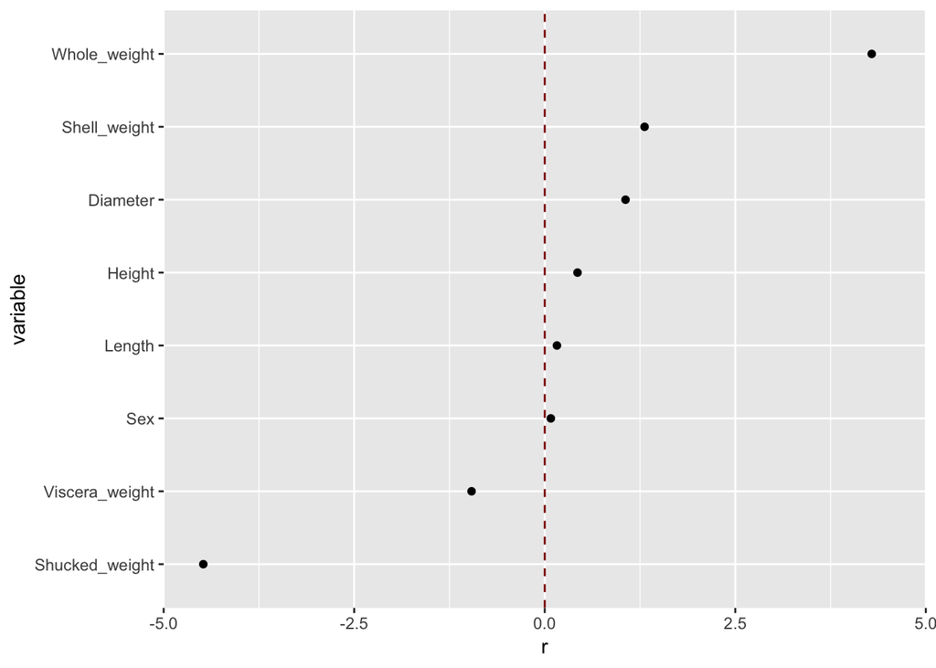

```r
#predict on test set
pred_lm <- predict(fit_lm, newdata = testing)

MAE_lm <- sum(abs(pred_lm - testing$Rings))/835
```

The MAE, using the linear model, is 1.6268601.

## Random Forest

Let’s give it another go using a random forest.

```r
fit_rf <- randomForest(Rings ~ ., data = training)

pred_rf <- predict(fit_rf, testing)

MAE_rf <- sum(abs(pred_rf - testing$Rings))/835
```

In this case the MAE is 1.5266701.

## Visualizing output

Let’s put this into context. The predictions for each model are compared to the actual data. The diagonal line is 1:1 equivalency.

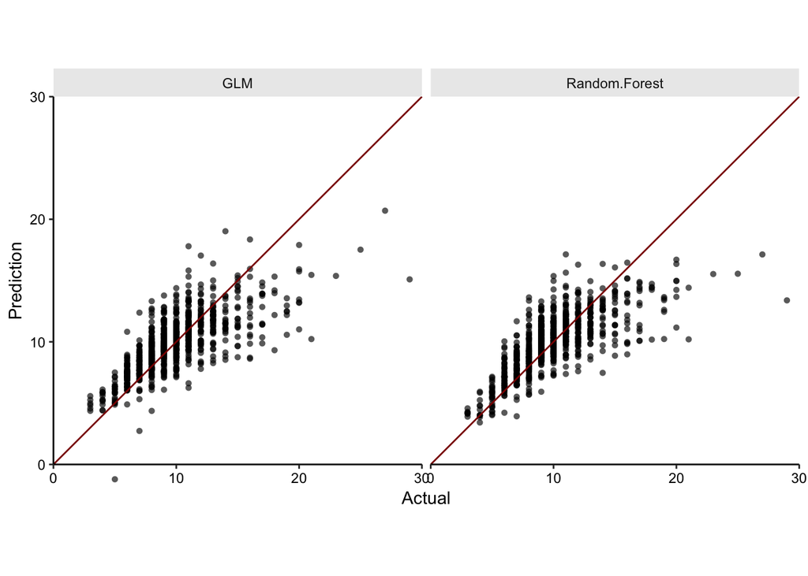

|  | Actual | GLM | Random.Forest |
| --- | --- | --- | --- |
| Actual | 1.0000000 | 0.7250482 | 0.7439216 |
| GLM | 0.7250482 | 1.0000000 | 0.9195314 |
| Random.Forest | 0.7439216 | 0.9195314 | 1.0000000 |